# RNA-Seq: quantification and DE analysis

Laura Toribio-Celestino

April 2025

### Loading required packages

```r
library(Rsubread)
library(DESeq2)
library(apeglm)
library(dplyr)
library(ggplot2)
library(pheatmap)
library(RColorBrewer)
library(EnhancedVolcano)
```

# Quantification with featureCounts

Let’s start by reading the sorted BAM files and the annotation SAF file located in this directory.

```r
bamfiles <- dir(".", ".bam$")
saffile <- dir(".", "saf$")
```

```r
fc <- featureCounts(bamfiles, annot.ext=saffile, strandSpecific=2, isPairedEnd=TRUE, nthreads=15)
```

[output not shown]

[output cut: 54 more lines]

```
## ||    Total alignments : 9032640                                              ||
## ||    Successfully assigned alignments : 7958757 (88.1%)                      ||
## ||    Running time : 1.18 minutes                                             ||
## ||                                                                            ||
## || Process BAM file K153_pVIM-1_3.bam...                                      ||
## ||    Strand specific : reversely stranded                                    ||
## ||    Paired-end reads are included.                                          ||
## ||    Total alignments : 10186201                                             ||
## ||    Successfully assigned alignments : 8967509 (88.0%)                      ||
## ||    Running time : 0.60 minutes                                             ||
## ||                                                                            ||
## || Write the final count table.                                               ||
## || Write the read assignment summary.                                         ||
## ||                                                                            ||
## \\============================================================================//
```

Count data is exported to a TSV file. Here we’ll see some stats of the count data.

```r
write.table(x=data.frame(fc$annotation[,c("GeneID","Chr", "Length")], fc$counts, stringsAsFactors=FALSE),
            file="featureCounts.tsv", quote=FALSE, sep="\t", row.names=FALSE)
head(fc$counts)
```

```
##              K153_PF_1.bam K153_PF_2.bam K153_PF_3.bam K153_pOXA-48_1.bam
## GIDKOH_00005            27            22            14                 27
## GIDKOH_00010            13            26            18                 26
## GIDKOH_00015             1             6             5                  0
## GIDKOH_00020           471           333           238                415
## GIDKOH_00025            44            38            16                 40
## GIDKOH_00030          1148           823           559                332
##              K153_pOXA-48_2.bam K153_pOXA-48_3.bam K153_pVIM-1_1.bam
## GIDKOH_00005                 37                 14                12
## GIDKOH_00010                 29                 16                17
## GIDKOH_00015                  3                  6                 2
## GIDKOH_00020                510                413               228
## GIDKOH_00025                 27                 23                41
## GIDKOH_00030                345                268               834
##              K153_pVIM-1_2.bam K153_pVIM-1_3.bam
## GIDKOH_00005                16                18
## GIDKOH_00010                24                34
## GIDKOH_00015                 4                 4
## GIDKOH_00020               207               240
## GIDKOH_00025                19                44
## GIDKOH_00030               631               707
```

```r
summary(fc$counts)
```

```
##  K153_PF_1.bam      K153_PF_2.bam      K153_PF_3.bam    K153_pOXA-48_1.bam
##  Min.   :     0.0   Min.   :     0.0   Min.   :     0   Min.   :     0.0
##  1st Qu.:    35.0   1st Qu.:    30.0   1st Qu.:    19   1st Qu.:    26.0
##  Median :   201.0   Median :   173.5   Median :   112   Median :   148.0
##  Mean   :  1918.5   Mean   :  1642.7   Mean   :  1108   Mean   :  1426.1
##  3rd Qu.:   864.2   3rd Qu.:   734.0   3rd Qu.:   486   3rd Qu.:   618.8
##  Max.   :447753.0   Max.   :360327.0   Max.   :247625   Max.   :213333.0
##  K153_pOXA-48_2.bam K153_pOXA-48_3.bam K153_pVIM-1_1.bam  K153_pVIM-1_2.bam
##  Min.   :     0     Min.   :     0.0   Min.   :     0.0   Min.   :     0.0
##  1st Qu.:    30     1st Qu.:    24.0   1st Qu.:    26.0   1st Qu.:    23.0
##  Median :   170     Median :   137.0   Median :   163.0   Median :   142.5
##  Mean   :  1595     Mean   :  1305.4   Mean   :  1477.0   Mean   :  1437.1
##  3rd Qu.:   709     3rd Qu.:   580.8   3rd Qu.:   717.8   3rd Qu.:   629.0
##  Max.   :266449     Max.   :182871.0   Max.   :245517.0   Max.   :293697.0
##  K153_pVIM-1_3.bam
##  Min.   :     0.0
##  1st Qu.:    26.0
##  Median :   162.5
##  Mean   :  1619.3
##  3rd Qu.:   740.8
##  Max.   :225171.0
```

```r
fc$stat
```

```
##                           Status K153_PF_1.bam K153_PF_2.bam K153_PF_3.bam
## 1                       Assigned      10624662       9097206       6136258
## 2            Unassigned_Unmapped         29520         16761         16314
## 3           Unassigned_Read_Type             0             0             0
## 4           Unassigned_Singleton             0             0             0
## 5      Unassigned_MappingQuality             0             0             0
## 6             Unassigned_Chimera             0             0             0
## 7      Unassigned_FragmentLength             0             0             0
## 8           Unassigned_Duplicate             0             0             0
## 9        Unassigned_MultiMapping             0             0             0
## 10          Unassigned_Secondary             0             0             0
## 11           Unassigned_NonSplit             0             0             0
## 12         Unassigned_NoFeatures        349241        309888        191838
## 13 Unassigned_Overlapping_Length             0             0             0
## 14          Unassigned_Ambiguity        685871        936659        570380
```

[output cut: 30 more lines]

The count matrices are prepared for the construction of the DESeqDataSet object. Gene IDs are set as row names.

```r
countdata <- fc$counts
colnames(countdata) <- gsub("\\.bam$", "", colnames(countdata))
nrow(countdata)
```

```
## [1] 5538
```

Plotting the total read counts of each sample.

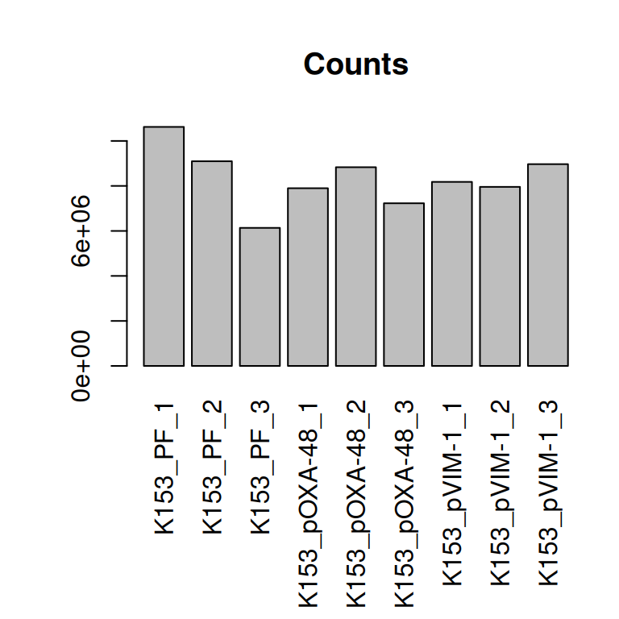

```r
par(mar=c(8,4,4,1)+0.1)
barplot(colSums(countdata), las=3, main="Counts")
```

# DESeqDataSet object and experimental design

Building the variables for the columns of the colData object. The condition of all samples and replicates is specified.

```r
condition <- c('PF', 'PF', 'PF', 'pOXA', 'pOXA', 'pOXA', 'pVIM', 'pVIM', 'pVIM')
replicate <- c('1', '2', '3', '1', '2', '3', '1', '2', '3')
coldata <- as.data.frame(cbind(colnames(countdata), condition, replicate))
coldata
```

```
##               V1 condition replicate
## 1      K153_PF_1        PF         1
## 2      K153_PF_2        PF         2
## 3      K153_PF_3        PF         3
## 4 K153_pOXA-48_1      pOXA         1
## 5 K153_pOXA-48_2      pOXA         2
## 6 K153_pOXA-48_3      pOXA         3
## 7  K153_pVIM-1_1      pVIM         1
## 8  K153_pVIM-1_2      pVIM         2
## 9  K153_pVIM-1_3      pVIM         3
```

Constructing the DESeqDataSet object.

```r
dds <- DESeqDataSetFromMatrix(countData = countdata, colData = coldata, design = ~ condition)
head(dds)
```

```
## class: DESeqDataSet
## dim: 6 9
## metadata(1): version
## assays(1): counts
## rownames(6): GIDKOH_00005 GIDKOH_00010 ... GIDKOH_00025 GIDKOH_00030
## rowData names(0):
## colnames(9): K153_PF_1 K153_PF_2 ... K153_pVIM-1_2 K153_pVIM-1_3
## colData names(3): V1 condition replicate
```

```r
nrow(dds)
```

```
## [1] 5538
```

Pre-filtering the dataset: Rows with 0 counts will be removed to increase the speed of the DESeq2 pipeline. Additional weighting/filtering to improve power is applied at a later step in the DESeq2 workflow.

```r
keep <- rowSums(counts(dds)) > 1
dds <- dds[keep,]
nrow(dds)
```

```
## [1] 5516
```

As there are three conditions, multiple comparisons are required. Thus, the dds object is duplicated to assign different reference levels to each. For dds1, the reference will be defined as the pOXA-48/pVIM-1-free version of the strain. For the comparison pVIM-1 vs pOXA-48, dds2 is releveled using the strain carrying pOXA-48 as reference.

```r
dds1 <- dds
dds2 <- dds
dds1$condition <- relevel(dds1$condition, ref = "PF")
dds2$condition <- relevel(dds2$condition, ref = "pOXA")
```

# Analysis of count data

Before exploratory analyses, count data is transformed to stabilize the variance across the mean. The rlog transformation is applied since it works best on small datasets (n<30), in comparison with the VST method.

```r
rld <- rlog(dds1, blind = FALSE)
head(assay(rld))
```

```
##              K153_PF_1 K153_PF_2 K153_PF_3 K153_pOXA-48_1 K153_pOXA-48_2
## GIDKOH_00005  4.321964  4.297128  4.276011       4.628221       4.791875
## GIDKOH_00010  3.879634  4.495788  4.535054       4.666124       4.646656
## GIDKOH_00015  1.521013  1.882056  1.950180       1.481863       1.708354
## GIDKOH_00020  8.455201  8.228300  8.341105       8.789587       8.882706
## GIDKOH_00025  5.006916  5.030443  4.661402       5.273080       4.790255
## GIDKOH_00030  9.709618  9.495282  9.541762       8.567624       8.438307
##              K153_pOXA-48_3 K153_pVIM-1_1 K153_pVIM-1_2 K153_pVIM-1_3
## GIDKOH_00005       4.174646      3.886786      4.154994      4.122957
## GIDKOH_00010       4.337578      4.174121      4.528977      4.692962
## GIDKOH_00015       1.973625      1.620752      1.790971      1.750058
## GIDKOH_00020       8.875439      7.738839      7.773039      7.758065
## GIDKOH_00025       4.832577      5.101580      4.547873      5.135105
## GIDKOH_00030       8.380539      9.512940      9.303181      9.244082
```

### Heatmap of distances between samples

To observe the similarities and dissimilarities between samples, we plot a heatmap of Euclidean distances. Replicates from each condition should cluster together.

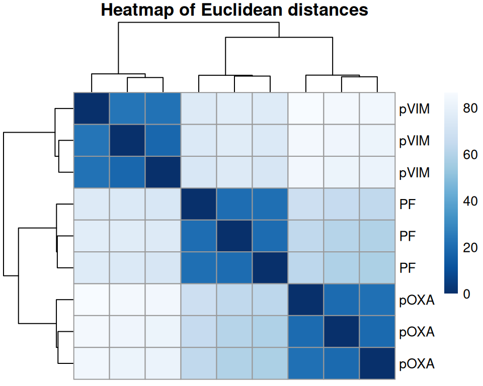

```r
sampleDists <- dist(t(assay(rld)))
sampleDistMatrix <- as.matrix(sampleDists)
rownames(sampleDistMatrix) <- paste(rld$condition, sep="-")
colnames(sampleDistMatrix) <- NULL
colors <- colorRampPalette(rev(brewer.pal(9, "Blues")))(255)
pheatmap(sampleDistMatrix,
         clustering_distance_rows=sampleDists,
         clustering_distance_cols=sampleDists,
         col=colors,
         main="Heatmap of Euclidean distances")
```

### PCA plot

In PCA plots, samples are projected onto the 2D plane such that they spread out in the two directions that explain most of the differences between them. The x-axis (PC1) is the direction that separates the data points the most. The y-axis (PC2) is the direction that separates the data the second most. The percent of the total variance that is contained in the direction is printed in the axis label. Replicates from each condition should cluster together.

```r
pcaData <- plotPCA(rld, intgroup = c("condition", "replicate"), returnData = TRUE)
```

```
## using ntop=500 top features by variance
```

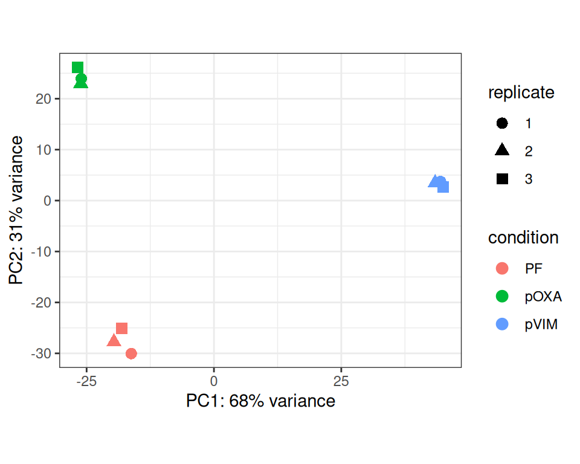

```r
percentVar <- round(100 * attr(pcaData, "percentVar"))
ggplot(pcaData, aes(x = PC1, y = PC2, color = condition, shape = replicate)) +
  geom_point(size =3) +
  xlab(paste0("PC1: ", percentVar[1], "% variance")) +
  ylab(paste0("PC2: ", percentVar[2], "% variance")) +
  coord_fixed() +
  theme_bw()
```

## Differential expression analysis

As we have already specified an experimental design when we created the DESeqDataSet, we can run the differential expression pipeline on the raw counts:

```r
dds1 <- DESeq(dds1)
resultsNames(dds1)
```

```
## [1] "Intercept"            "condition_pOXA_vs_PF" "condition_pVIM_vs_PF"
```

```r
dds2 <- DESeq(dds2)
resultsNames(dds2)
```

```
## [1] "Intercept"              "condition_PF_vs_pOXA"   "condition_pVIM_vs_pOXA"
```

We’ll have a look at the summary of the unfiltered DE results. The LFC is shrunken with the apeglm method for visualizing results and ranking the genes for GSEA analysis.

```r
res_pOXA_PF <- lfcShrink(dds1, coef="condition_pOXA_vs_PF", type="apeglm")
```

```
## using 'apeglm' for LFC shrinkage. If used in published research, please cite:
##     Zhu, A., Ibrahim, J.G., Love, M.I. (2018) Heavy-tailed prior distributions for
##     sequence count data: removing the noise and preserving large differences.
##     Bioinformatics. https://doi.org/10.1093/bioinformatics/bty895
```

```r
summary(res_pOXA_PF)
```

```
##
## out of 5516 with nonzero total read count
## adjusted p-value < 0.1
## LFC > 0 (up)       : 1209, 22%
## LFC < 0 (down)     : 993, 18%
## outliers [1]       : 0, 0%
## low counts [2]     : 107, 1.9%
## (mean count < 1)
## [1] see 'cooksCutoff' argument of ?results
## [2] see 'independentFiltering' argument of ?results
```

```r
res_pVIM_PF <- lfcShrink(dds1, coef="condition_pVIM_vs_PF", type="apeglm")
```

```
## using 'apeglm' for LFC shrinkage. If used in published research, please cite:
##     Zhu, A., Ibrahim, J.G., Love, M.I. (2018) Heavy-tailed prior distributions for
##     sequence count data: removing the noise and preserving large differences.
##     Bioinformatics. https://doi.org/10.1093/bioinformatics/bty895
```

```r
summary(res_pVIM_PF)
```

```
##
## out of 5516 with nonzero total read count
## adjusted p-value < 0.1
## LFC > 0 (up)       : 521, 9.4%
## LFC < 0 (down)     : 772, 14%
## outliers [1]       : 0, 0%
## low counts [2]     : 0, 0%
## (mean count < 0)
## [1] see 'cooksCutoff' argument of ?results
## [2] see 'independentFiltering' argument of ?results
```

```r
res_pVIM_pOXA <- lfcShrink(dds2, coef="condition_pVIM_vs_pOXA", type="apeglm")
```

```
## using 'apeglm' for LFC shrinkage. If used in published research, please cite:
##     Zhu, A., Ibrahim, J.G., Love, M.I. (2018) Heavy-tailed prior distributions for
##     sequence count data: removing the noise and preserving large differences.
##     Bioinformatics. https://doi.org/10.1093/bioinformatics/bty895
```

```r
summary(res_pVIM_pOXA)
```

```
##
## out of 5516 with nonzero total read count
## adjusted p-value < 0.1
## LFC > 0 (up)       : 1215, 22%
## LFC < 0 (down)     : 1449, 26%
## outliers [1]       : 0, 0%
## low counts [2]     : 0, 0%
## (mean count < 0)
## [1] see 'cooksCutoff' argument of ?results
## [2] see 'independentFiltering' argument of ?results
```

The unfiltered DE results are exported to a TSV file (contains NAs and non-significant DEGs).

```r
## The saf file, which contains the UniRef IDs is read
saftable <- read.csv(saffile, header=TRUE, sep="\t")
saftable <- as.data.frame(saftable)

## Merge with normalized count data and annotation
resdata_pOXA_PF <- merge(as.data.frame(res_pOXA_PF), as.data.frame(counts(dds1, normalized=TRUE)), by="row.names", sort=FALSE)
names(resdata_pOXA_PF)[1] <- "GeneID"
resdata_pOXA_PF <- merge(x=as.data.frame(resdata_pOXA_PF), saftable, by="GeneID")

resdata_pVIM_PF <- merge(as.data.frame(res_pVIM_PF), as.data.frame(counts(dds1, normalized=TRUE)), by="row.names", sort=FALSE)
names(resdata_pVIM_PF)[1] <- "GeneID"
resdata_pVIM_PF <- merge(x=as.data.frame(resdata_pVIM_PF), saftable, by="GeneID")

resdata_pVIM_pOXA <- merge(as.data.frame(res_pVIM_pOXA), as.data.frame(counts(dds2, normalized=TRUE)), by="row.names", sort=FALSE)
names(resdata_pVIM_pOXA)[1] <- "GeneID"
resdata_pVIM_pOXA <- merge(x=as.data.frame(resdata_pVIM_pOXA), saftable, by="GeneID")

## Write results
write.table(resdata_pOXA_PF, file="DE_results_pOXA-48-vs-PF_raw.tsv", sep="\t", row.names=FALSE)
write.table(resdata_pVIM_PF, file="DE_results_pVIM-1-vs-PF_raw.tsv", sep="\t", row.names=FALSE)
write.table(resdata_pVIM_pOXA, file="DE_results_pVIM-1-vs-pOXA-48_raw.tsv", sep="\t", row.names=FALSE)
```

Lowering the FDR threshold on padj (Benjamini-Hochberg adjusted p-values).

```r
resfilt_pOXA_PF <- results(dds1, alpha = 0.05, contrast=c("condition", "pOXA", "PF"))
summary(resfilt_pOXA_PF)
```

```
##
## out of 5516 with nonzero total read count
## adjusted p-value < 0.05
## LFC > 0 (up)       : 1062, 19%
## LFC < 0 (down)     : 856, 16%
## outliers [1]       : 0, 0%
## low counts [2]     : 428, 7.8%
## (mean count < 5)
## [1] see 'cooksCutoff' argument of ?results
## [2] see 'independentFiltering' argument of ?results
```

```r
resfilt_pVIM_PF <- results(dds1, alpha = 0.05, contrast=c("condition", "pVIM", "PF"))
summary(resfilt_pVIM_PF)
```

```
##
## out of 5516 with nonzero total read count
## adjusted p-value < 0.05
## LFC > 0 (up)       : 433, 7.8%
## LFC < 0 (down)     : 687, 12%
## outliers [1]       : 0, 0%
## low counts [2]     : 214, 3.9%
## (mean count < 3)
## [1] see 'cooksCutoff' argument of ?results
## [2] see 'independentFiltering' argument of ?results
```

```r
resfilt_pVIM_pOXA <- results(dds2, alpha = 0.05, contrast=c("condition", "pVIM", "pOXA"))
summary(resfilt_pVIM_pOXA)
```

```
##
## out of 5516 with nonzero total read count
## adjusted p-value < 0.05
## LFC > 0 (up)       : 1083, 20%
## LFC < 0 (down)     : 1315, 24%
## outliers [1]       : 0, 0%
## low counts [2]     : 214, 3.9%
## (mean count < 3)
## [1] see 'cooksCutoff' argument of ?results
## [2] see 'independentFiltering' argument of ?results
```

```r
## Creating a results data frame filtered by padj and LFC
resFilt_pOXA_PF <- subset(resfilt_pOXA_PF, padj < 0.05)
resFilt_pVIM_PF <- subset(resfilt_pVIM_PF, padj < 0.05)
resFilt_pVIM_pOXA <- subset(resfilt_pVIM_pOXA, padj < 0.05)

## Merge with normalized count data and annotation
resdatafilt_pOXA_PF <- merge(as.data.frame(resFilt_pOXA_PF), as.data.frame(counts(dds1, normalized=TRUE)), by="row.names", sort=FALSE)
names(resdatafilt_pOXA_PF)[1] <- "GeneID"
resdatafilt_pOXA_PF <- merge(x=as.data.frame(resdatafilt_pOXA_PF), saftable, by="GeneID")

resdatafilt_pVIM_PF <- merge(as.data.frame(resFilt_pVIM_PF), as.data.frame(counts(dds1, normalized=TRUE)), by="row.names", sort=FALSE)
names(resdatafilt_pVIM_PF)[1] <- "GeneID"
resdatafilt_pVIM_PF <- merge(x=as.data.frame(resdatafilt_pVIM_PF), saftable, by="GeneID")

resdatafilt_pVIM_pOXA <- merge(as.data.frame(resFilt_pVIM_pOXA), as.data.frame(counts(dds2, normalized=TRUE)), by="row.names", sort=FALSE)
names(resdatafilt_pVIM_pOXA)[1] <- "GeneID"
resdatafilt_pVIM_pOXA <- merge(x=as.data.frame(resdatafilt_pVIM_pOXA), saftable, by="GeneID")

## Order by log2FC
resdatafilt_pOXA_PF <- resdatafilt_pOXA_PF[order(resdatafilt_pOXA_PF$log2FoldChange, decreasing = TRUE), ]
resdatafilt_pVIM_PF <- resdatafilt_pVIM_PF[order(resdatafilt_pVIM_PF$log2FoldChange, decreasing = TRUE), ]
resdatafilt_pVIM_pOXA <- resdatafilt_pVIM_pOXA[order(resdatafilt_pVIM_pOXA$log2FoldChange, decreasing = TRUE), ]

## Write results
write.table(resdatafilt_pOXA_PF, file="DE_results_pOXA-48-vs-PF_filtered_padj.tsv", sep="\t", row.names=FALSE)
write.table(resdatafilt_pVIM_PF, file="DE_results_pVIM-1-vs-PF_filtered_padj.tsv", sep="\t", row.names=FALSE)
write.table(resdatafilt_pVIM_pOXA, file="DE_results_pVIM-1-vs-pOXA-48_filtered_padj.tsv", sep="\t", row.names=FALSE)
```

### MA plot

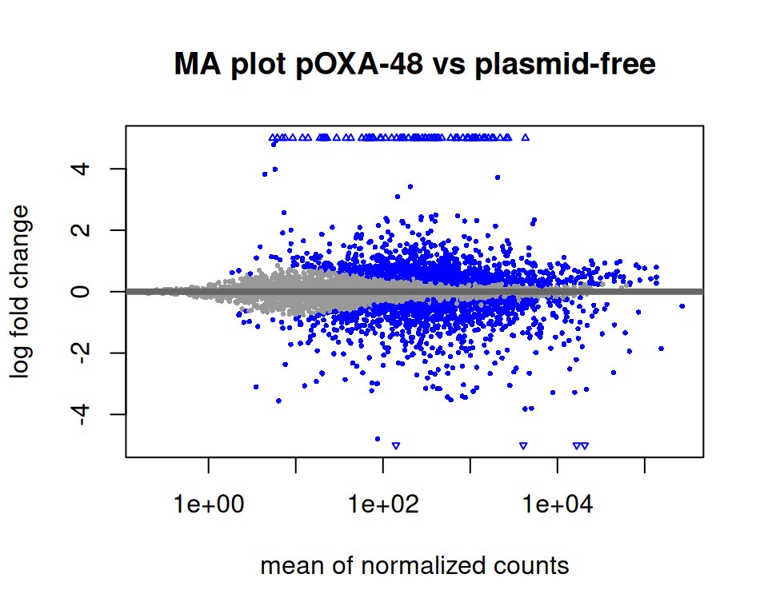

```r
DESeq2::plotMA(res_pOXA_PF, ylim=c(-5,5), main="MA plot pOXA-48 vs plasmid-free")
```

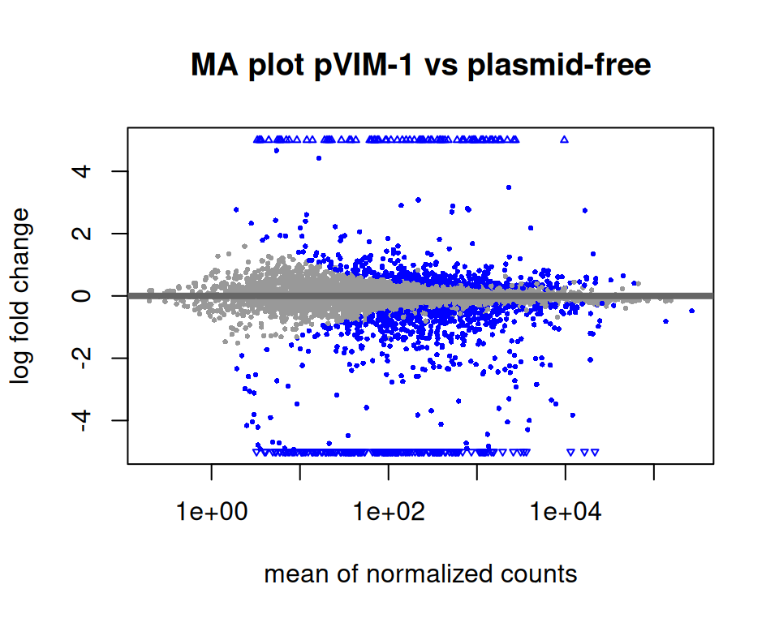

```r
DESeq2::plotMA(res_pVIM_PF, ylim=c(-5,5), main="MA plot pVIM-1 vs plasmid-free")
```

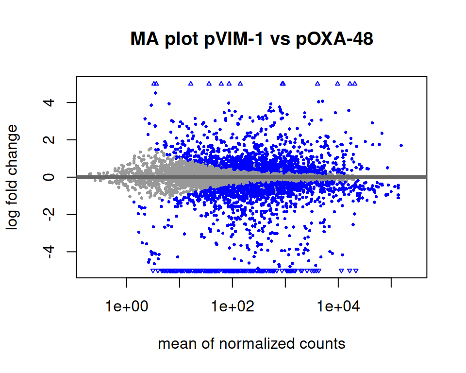

```r
DESeq2::plotMA(res_pVIM_pOXA, ylim=c(-5,5), main="MA plot pVIM-1 vs pOXA-48")
```

### Volcano plot

The volcano plot arranges genes along two dimensions: the x-axis is the log fold change between the two groups, and the y-axis represents the adjusted P values between samples (on a negative log scale so smaller p-values appear higher up).

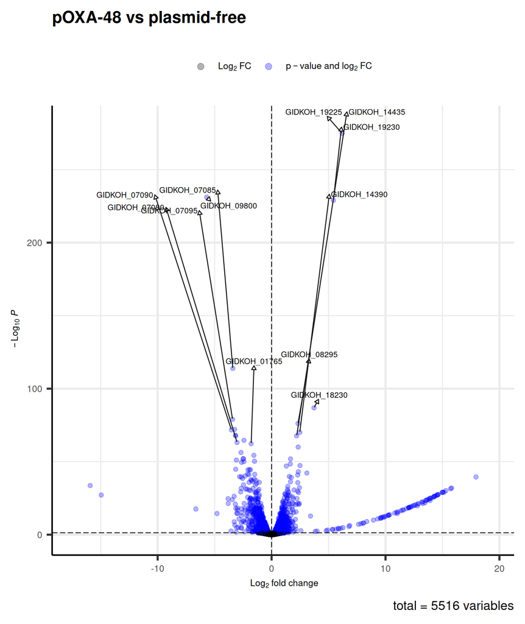

```r
EnhancedVolcano(res_pOXA_PF, lab = rownames(res_pOXA_PF), x = 'log2FoldChange', y = 'padj', pCutoff=0.05, FCcutoff=0, subtitleLabSize=0, axisLabSize=10, labSize=3, legendLabSize=10, legendIconSize=3, col=c('black', 'black', 'gold2', 'blue'), colAlpha = 0.3, drawConnectors = TRUE, title="pOXA-48 vs plasmid-free")
```

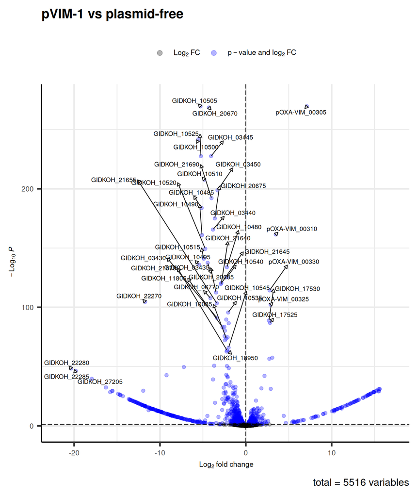

```r
EnhancedVolcano(res_pVIM_PF, lab = rownames(res_pVIM_PF), x = 'log2FoldChange', y = 'padj', pCutoff=0.05, FCcutoff=0, subtitleLabSize=0, axisLabSize=10, labSize=3, legendLabSize=10, legendIconSize=3, col=c('black', 'black', 'gold2', 'blue'), colAlpha = 0.3, drawConnectors = TRUE, title="pVIM-1 vs plasmid-free")
```

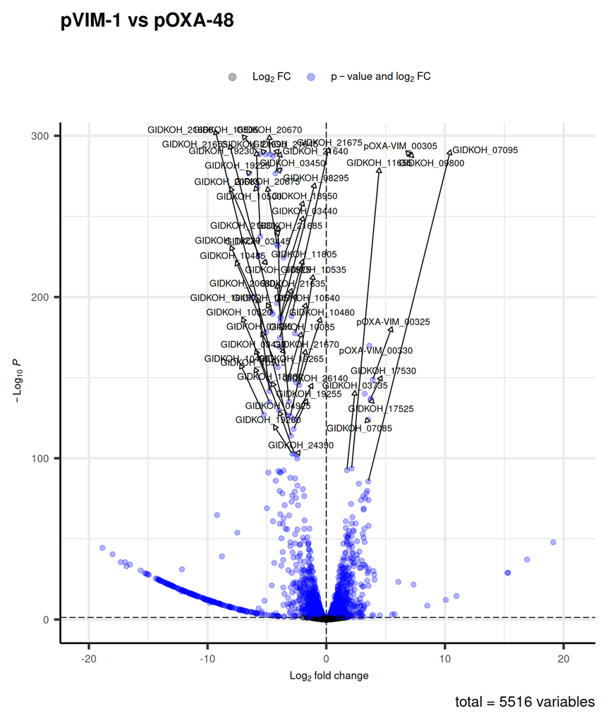

```r
EnhancedVolcano(res_pVIM_pOXA, lab = rownames(res_pVIM_pOXA), x = 'log2FoldChange', y = 'padj', pCutoff=0.05, FCcutoff=0, subtitleLabSize=0, axisLabSize=10, labSize=3, legendLabSize=10, legendIconSize=3, col=c('black', 'black', 'gold2', 'blue'), colAlpha = 0.3, drawConnectors = TRUE, title="pVIM-1 vs pOXA-48")
```